# 언어심리학을 위한 데이터 사이언스 5주차: 데이터 사이언스 #3 (데이터 시각화)

## (17) 퀵 플롯(quick plot) 생성하기

- 기능: 데이터의 대략적 경향을 파악하기 위해 `qplot` 함수를 통해 빠르게 간단한 플롯(quick plot) 생성.

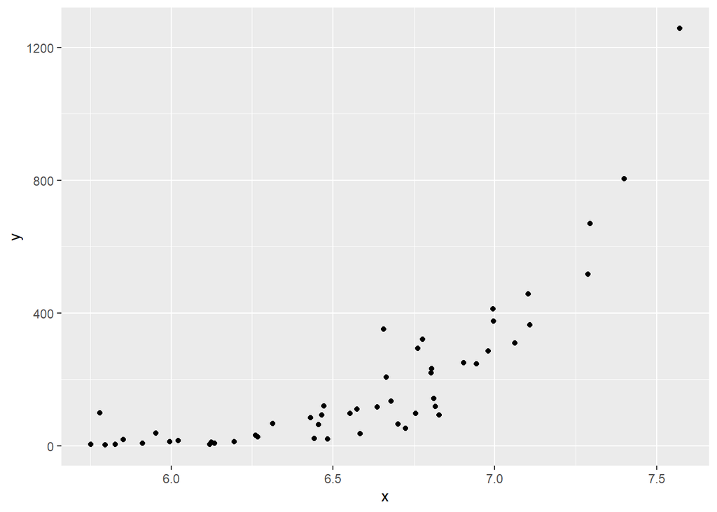

```r
# qplot 함수를 사용하여 빠르게 간단한 플롯 생성하기.
data(murders)
x <- log10(murders$population)
y <- murders$total
qplot(x, y)
```

## (18) **gridExtra** 패키지를 사용하여 플롯 그리드(grid) 생성하기

- 기능: 여러 개의 플롯을 나란히 병치할 수 있음.

```r
# gridExtra 패키지를 사용하여 두 개의 플롯을 나란히 병치하기.
library(gridExtra)
```

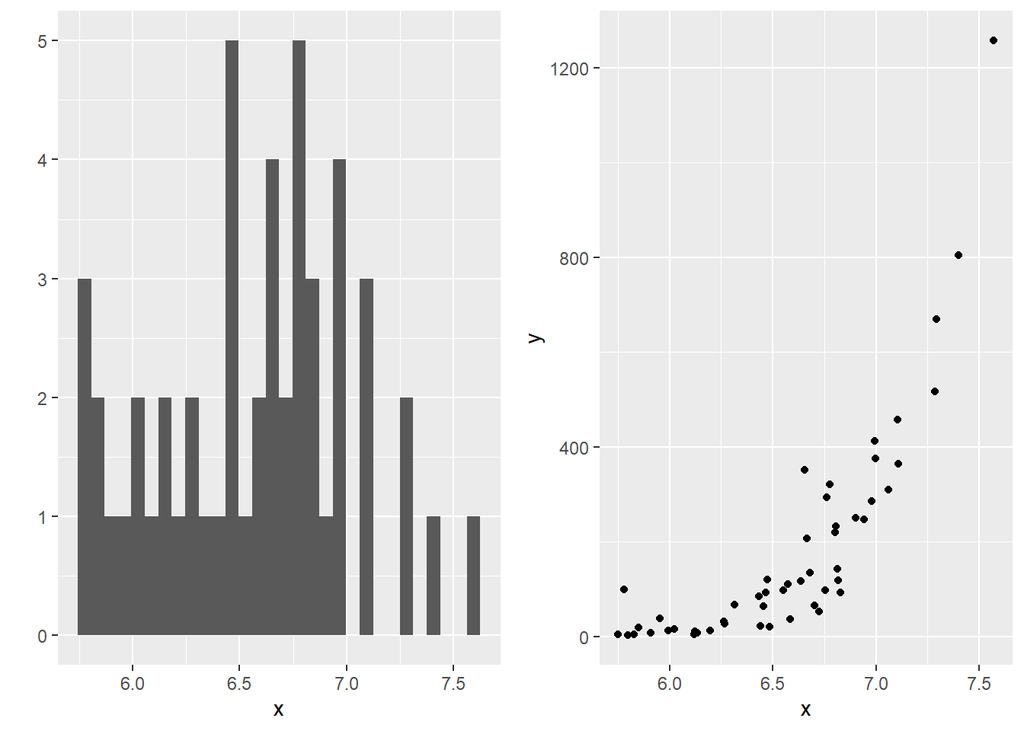

```r
p1 <- qplot(x)
p2 <- qplot(x,y)
grid.arrange(p1, p2, ncol = 2)
```

# 3. **ggplot2** 패키지를 사용한 데이터 분포(data distribution) 시각화

## (1) 막대 그래프(barplot)

- 함수: `geom_bar` 지오메트리를 사용하여 생성.
  - 디폴트 설정: 각 범주의 빈도를 구하여 막대 그리기. 빈도가 y축, 범주가 x축이 됨.
  - 예시: y축이 빈도가 아닌 비율(`proportion`)이 되도록 막대 그리기.

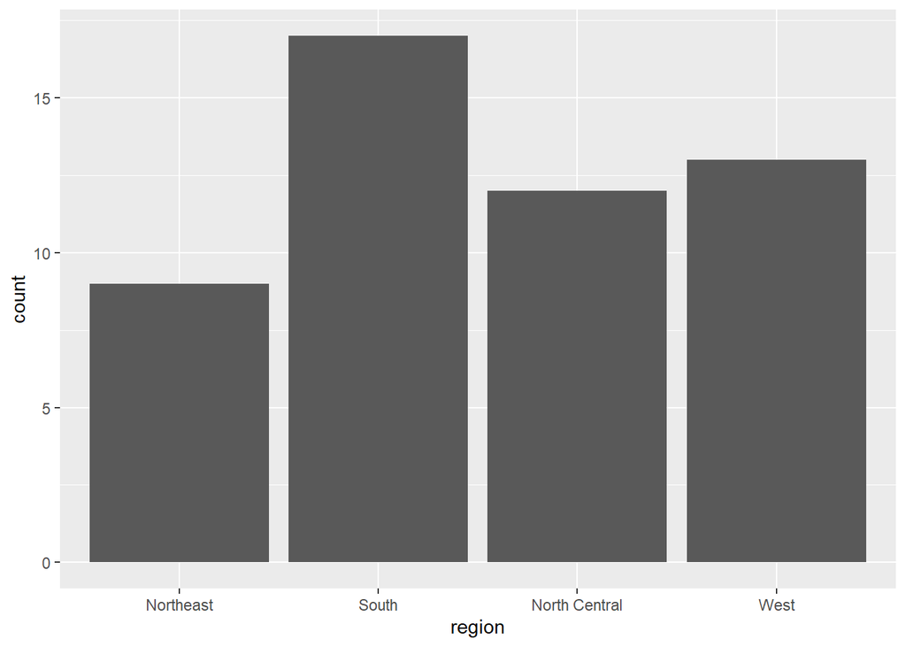

```r
# 미국의 각 지역(region)별로 막대 그래프 생성하기.
murders %>%
  ggplot(aes(region)) + geom_bar()
```

- `stat` 논항: `proportion` 변수가 y축이 되도록 하려면, `proportion` 변수가 막대의 높이를 결정한다는 것을 정의해 주어야 함. 이를 위해 `geom_bar` 함수에 `stat = "identity"` 논항을 추가해야 함.

```r
tab <- murders %>%
  count(region) %>%
  mutate(proportion = n/sum(n))
tab
```

```
##          region  n proportion
## 1     Northeast  9  0.1764706
## 2         South 17  0.3333333
## 3 North Central 12  0.2352941
## 4          West 13  0.2549020
```

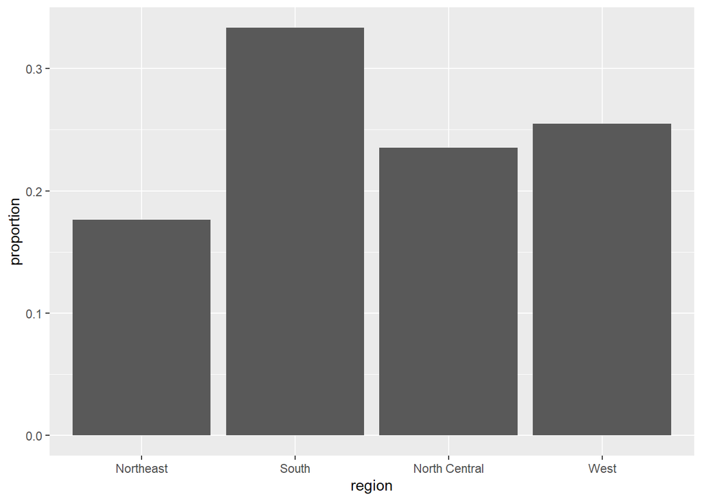

```r
# 빈도 대신 비율이 y축이 되도록 막대 그리기.
tab %>%
  ggplot(aes(region, proportion)) +
  geom_bar(stat = "identity")
```

## (2) 히스토그램(histogram)

- 함수: `geom_histogram` 지오메트리를 사용하여 생성.
  - 디폴트 설정: x축에 해당하는 논항만 있으면 됨.
  - `aes` 함수에 이미 x축에 해당하는 `height` 변수가 포함되어 있으므로, `geom_histogram` 함수에는 아무 논항도 넣칮 않아도 됨.

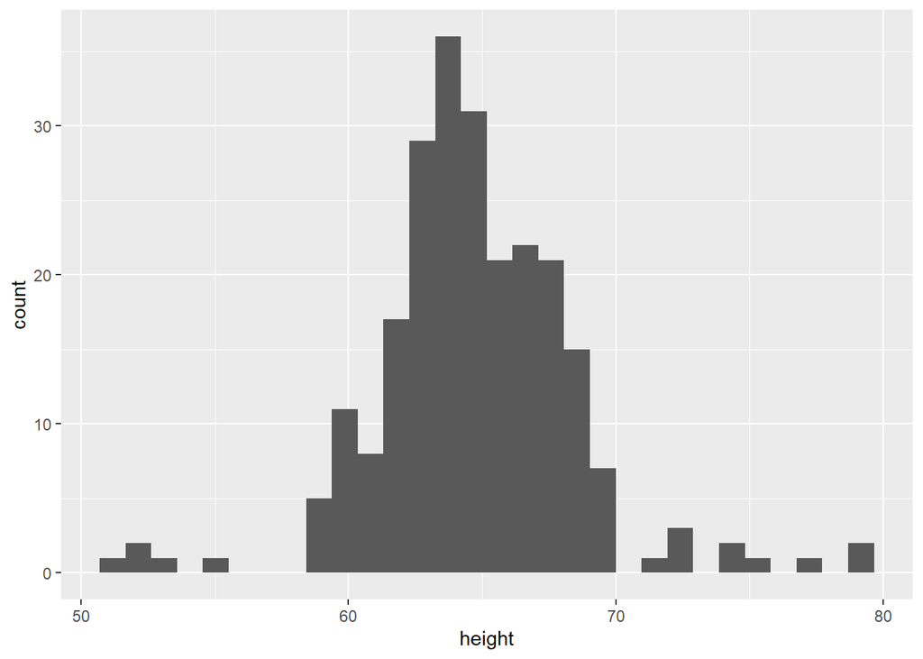

```r
# heights 데이터셋 중 여성 키에 대한 히스토그램 그리기.
heights %>%
  filter(sex == "Female") %>%
  ggplot(aes(height)) +
  geom_histogram()
```

- 논항
  - `binwidth`: 상기 코드 실행 시 아래와 같은 메시지가 나타남. 따라서 `binwidth` 논항을 사용하여 히스토그램의 모양을 개선할 필요가 있음. `bins`는 히스토그램 막대의 수를 가리킴.

> `stat_bin()` using `bins = 30`. Pick better value with `binwidth`.
- `fill`: 막대 안쪽 색상 정의.
- `col`: 막대 테두리 색상 정의.

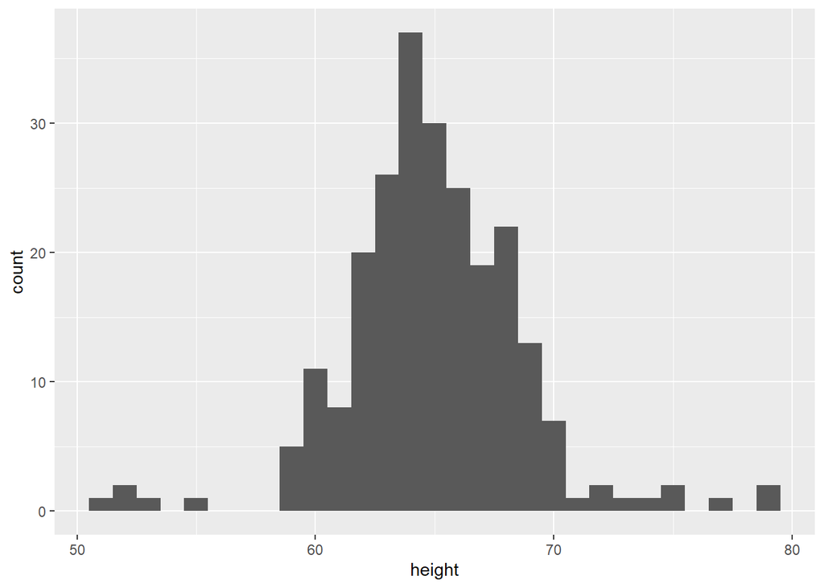

```r
# heights 데이터셋 중 여성의 키에 대한 히스토그램 그리기: binwidth = 1.
heights %>%
  filter(sex == "Female") %>%
  ggplot(aes(height)) +
  geom_histogram(binwidth = 1)
```

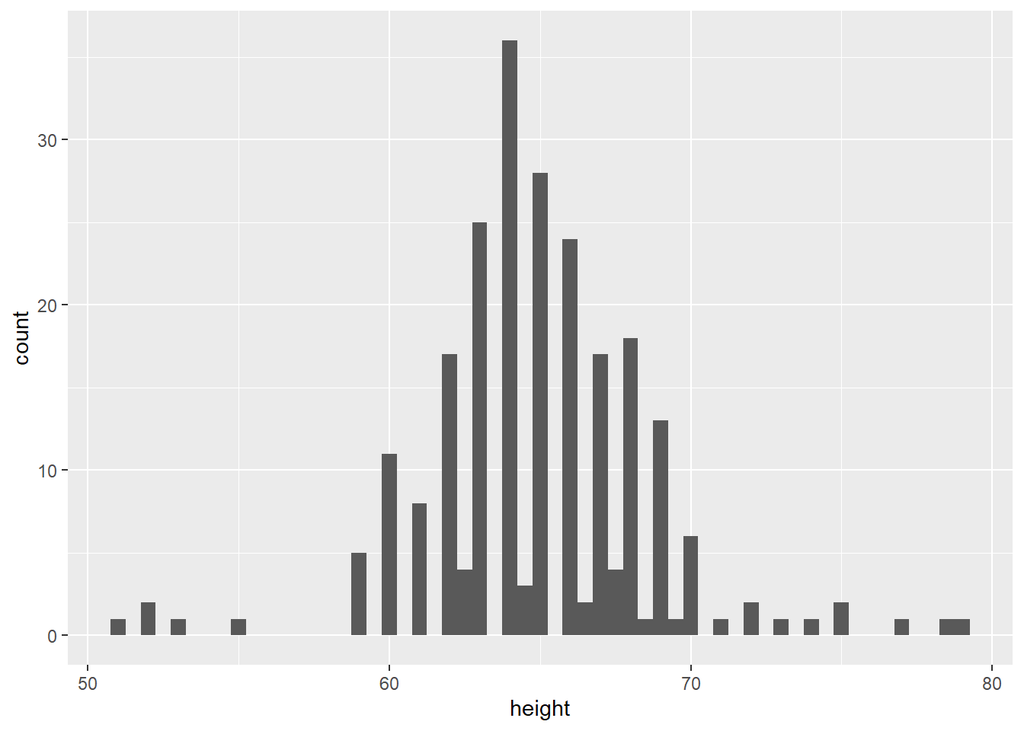

```r
# heights 데이터셋 중 여성의 키에 대한 히스토그램 그리기: binwidth = 0.5.
heights %>%
  filter(sex == "Female") %>%
  ggplot(aes(height)) +
  geom_histogram(binwidth = 0.5)
```

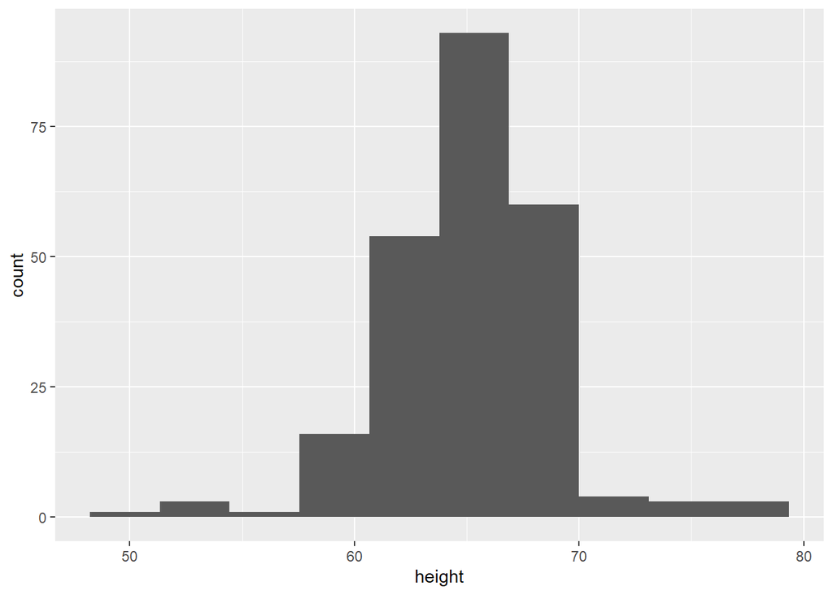

```r
# heights 데이터셋 중 여성의 키에 대한 히스토그램 그리기: bins = 10.
heights %>%
  filter(sex == "Female") %>%
  ggplot(aes(height)) +
  geom_histogram(bins = 10)
```

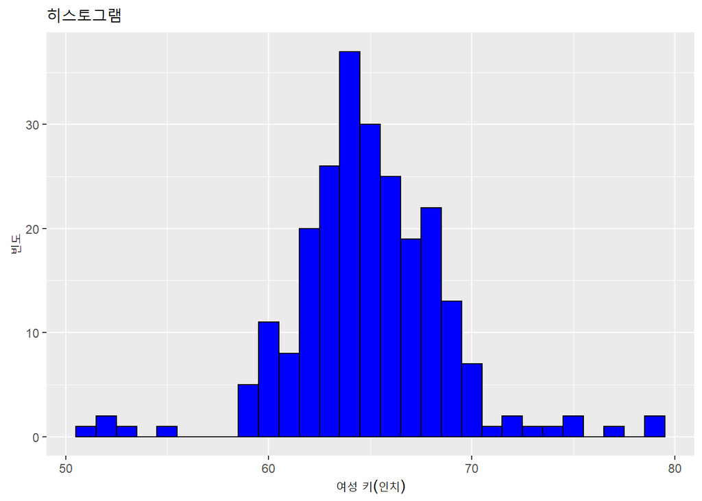

```r
# x축 레이블 변경 및 히스토그램 제목 추가하기.
heights %>%
  filter(sex == "Female") %>%
  ggplot(aes(height)) +
  geom_histogram(binwidth = 1, fill = "blue", col = "black") + # 막대 색상을 파란색으로, 테두리 색상을 검정색으로 정의.
  xlab("여성 키(인치)") +
  ylab("빈도") +
  ggtitle("히스토그램")
```

## (3) 밀도 플롯(density plot)

- 함수
  - `geom_density` 지오메트리를 사용하여 생성.
  - 히스토그램을 평탄화된(smooth) 밀도 플롯으로 바꾸려면 아래와 같이 코드를 작성.

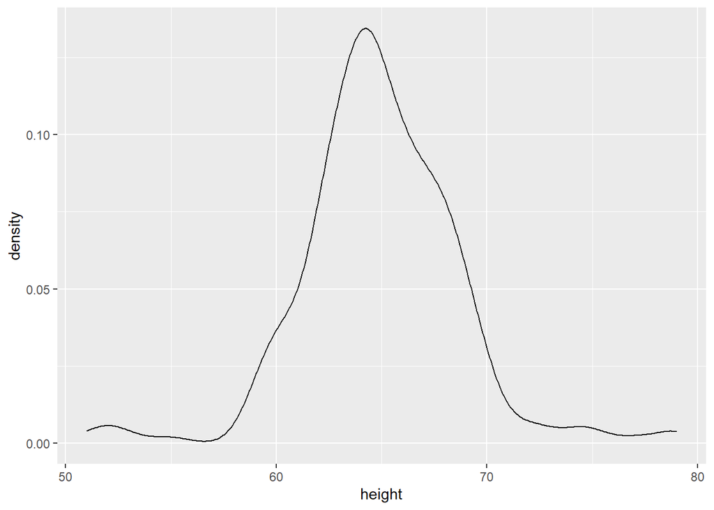

```r
# heights 데이터셋 중 여성의 키에 대한 밀도 플롯 그리기.
heights %>%
  filter(sex == "Female") %>%
  ggplot(aes(height)) +
  geom_density()
```

- 논항
  - `fill`: 플롯 안쪽 색상 정의.
  - `adjust`: 밀도의 평탄화 정도(smoothness)를 변경하기 위해 `adjust` 논항을 통해 디폴트 값에 특정 숫자를 곱해줌. 숫자가 커질수록 밀도 플롯이 평탄해짐.

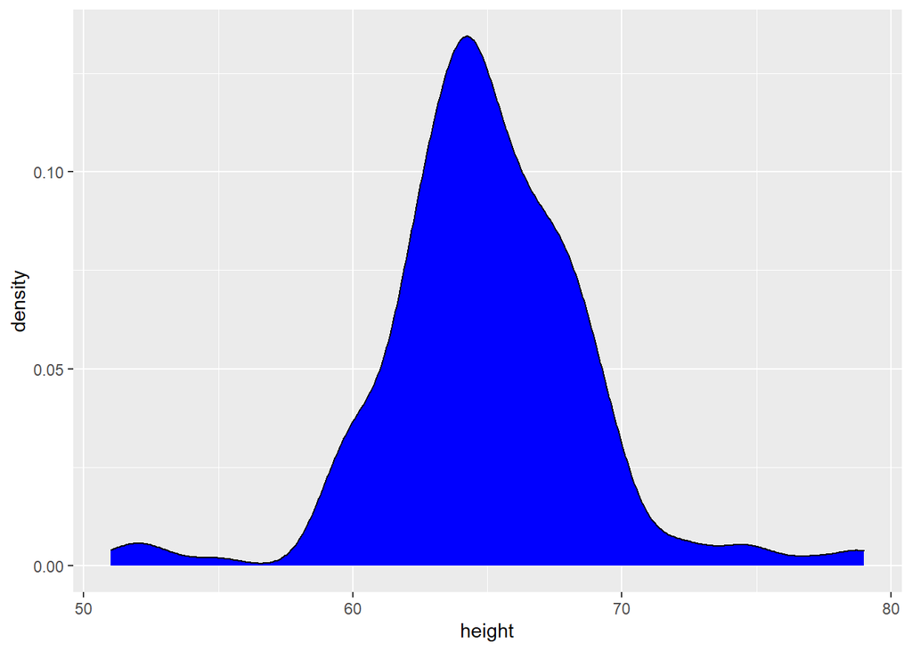

```r
# heights 데이터셋 중 여성의 키에 대한 밀도 플롯 그리기.
heights %>%
  filter(sex == "Female") %>%
  ggplot(aes(height)) +
  geom_density(fill="blue") # 밀도 플롯 안쪽을 파란색으로 칠하기.
```

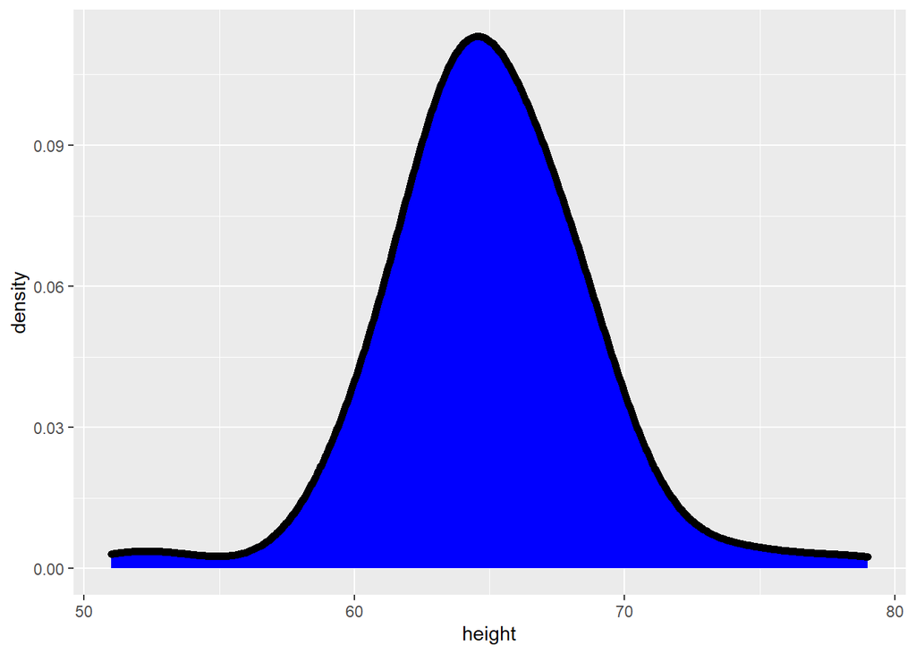

```r
# heights 데이터셋 중 여성의 키에 대한 밀도 플롯 그리기.
heights %>%
  filter(sex == "Female") %>%
  ggplot(aes(height)) +
  geom_density(fill="blue", adjust = 2, lwd = 2) # fill 논항으로 플롯 파란색으로 칠하기 & adjust 논항으로 플롯 평탄화하기 & 선 굵기 2로 설정하기.
```

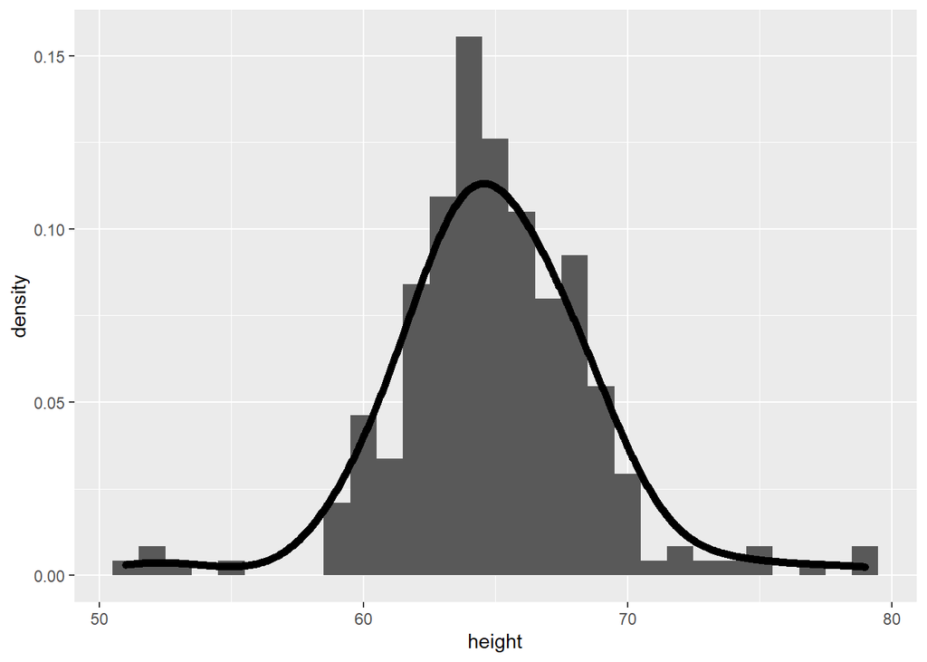

```r
# 히스토그램과 밀도 플롯 겹쳐 그리기.
heights %>%
  filter(sex == "Female") %>%
  ggplot(aes(height)) +
  geom_histogram(aes(y = ..density..), binwidth = 1) + # aes 논항에서 y축을 ..density..로 설정해야 히스토그램 위에 밀도 플롯을 겹쳐 그릴 수 있음.
  geom_density(adjust = 2, lwd = 2)
```

## (4) 상자 그래프(boxplot)

- 함수
  - `geom_boxplot` 지오메트리를 사용하여 생성.
  - 기능: 여러 개의 분포를 비교할 때 유용. [EX] 여성과 남성의 키 비교.
  - 플롯 설명: median, upper hinge, lower hinge, upper whisker, lower whisker, outliers.
- 논항: `x` 논항은 범주변수, `y` 논항은 관찰값에 해당.

**[그림 3] geom_boxplot 설명**

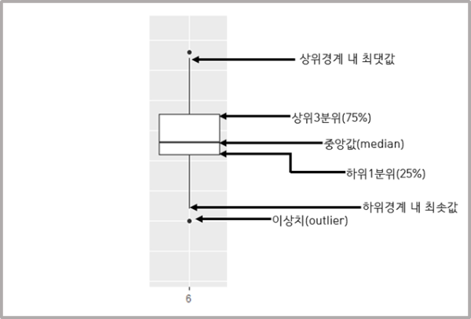

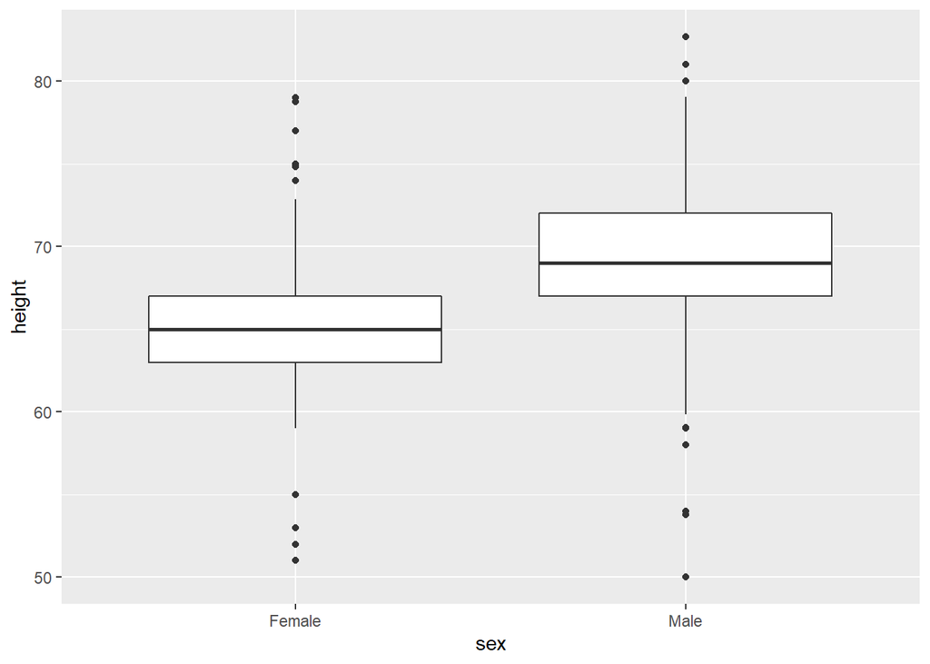

```r
# heights 데이터셋의 남녀 키 비교를 위한 상자 그래프 그리기.
heights %>%
  ggplot(aes(x = sex, y = height)) + # 범주변수는 성별(남 vs. 여), 관찰값은 키.
  geom_boxplot()
```

## (5) QQ-플롯(QQ-plot)

- 함수
  - `geom_qq` 지오메트리를 사용하여 생성.
  - sample 값과 평균이 0 & 표준편차가 1인 정규분포를 비교함. ⇒ 분포 모양이 사선으로 일직선을 이룰 경우 정규분포에 가깝다고 판정 가능.
- 논항
  - `aes` 함수에 `sample` 논항 넣기.
  - `geom_qq` 함수에 `dparams` 논항(분포[distribution] 함수에 들어가는 모수[parameter] 논항) 넣기기.

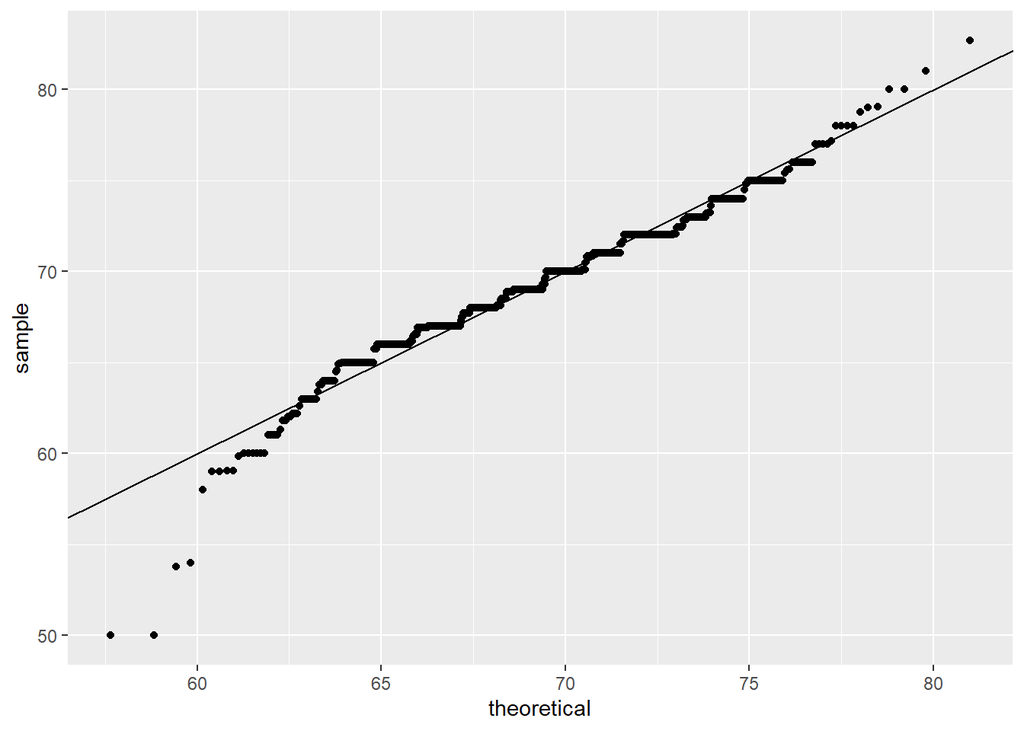

```r
# 남성 키 데이터의 모수(평균과 표준편차) 계산하기.
params <- heights %>% filter(sex=="Male") %>%
  summarize(mean = mean(height), sd = sd(height))

# 선택지 1: geom_qq 함수로 남성 키 데이터에 대한 QQ-플롯 그리기.
heights %>%
  filter(sex=="Male") %>%
  ggplot(aes(sample = height)) +
  geom_qq(dparams = params) + # dparams 논항을 params 객체(남성 키의 평균과 표준편차)로 정의하기.
  geom_abline() # 기울기가 1이고 절편이 0인 정규분포 선 삽입하여 샘플 분포 패턴과 비교하기.
```

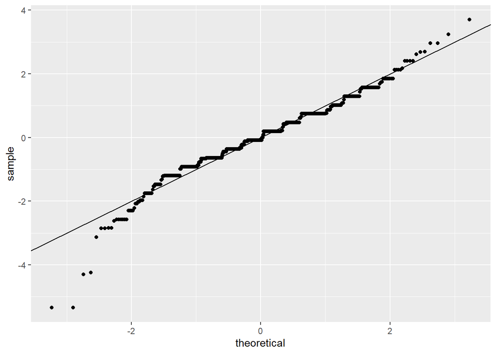

```r
# 선택지 2: geom_qq 함수로 남성 키 데이터에 대한 QQ-플롯 그리기.
heights %>%
  filter(sex=="Male") %>%
  ggplot(aes(sample = scale(height))) + # 데이터를 평균이 0이고 표준편차가 1인 표준점수로 변환하기.
  geom_qq() + # QQ-플롯을 기울기가 1이고 절편이 0인 정규분포 선과 대조하기.
  geom_abline()
```

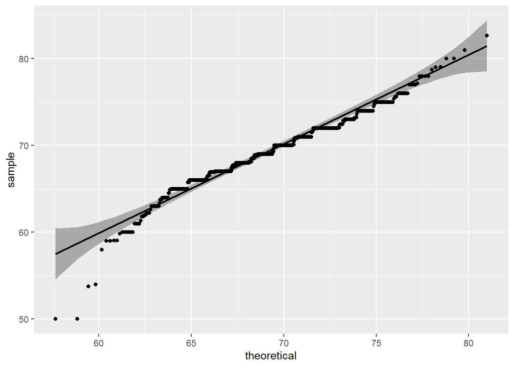

```r
# 선택지 3: qqplotr 패키지 사용하기.
library(qqplotr)
heights %>%
  filter(sex=="Male") %>%
  ggplot(aes(sample = height)) +
  stat_qq_band() +
  stat_qq_line() +
  stat_qq_point()
```

## (6) 퀵 플롯(qplot)

- 함수
  - `qplot` 지오메트리를 사용하여 생성.
  - 기능: 산점도, 히스토그램, 밀도 플롯, 상자 그래프, QQ-플롯 등을 쉽고 간단하게 그려볼 때 유용.

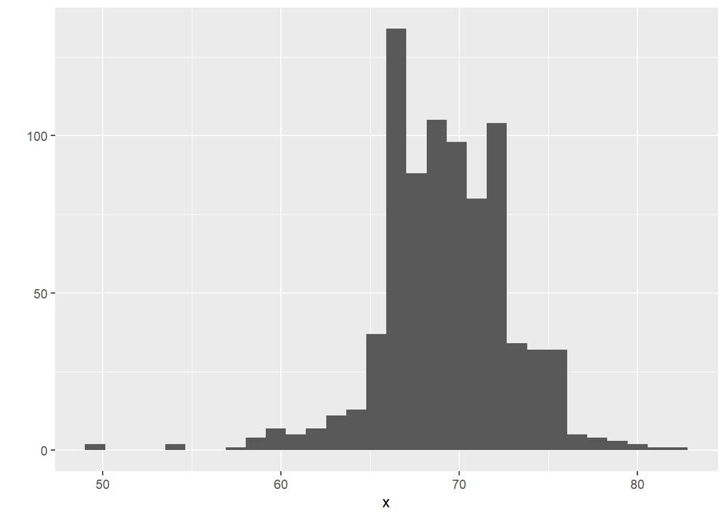

```r
# 남성 키 벡터를 x 변수에 할당.
x <- heights %>%
  filter(sex=="Male") %>%
  pull(height)

# 남성 키 벡터 x에 대한 퀵 플롯 히스토그램 그려보기.
qplot(x)
```

- 논항
  - 한 개의 논항 투입 시 히스토그램 그려줌.
  - 두 개의 논항 투입 시 산점도 그려줌.
  - 지오메트리 정의: `geom` 논항 투입 시 지오메토리([EX] `boxplot`, `density`, `jitter` 등) 정의 가능.
  - 퀵 플롯 스타일 상세화: `bins`(히스토그램의 막대 수), `color/colour`(막대/포인트 색상), `xlab`(x축 레이블) 등의 논항을 추가할 경우, 퀵 플롯의 결과를 좀더 상세하게 구현할 수 있음.
- 레이어 추가: 퀵 플롯도 `+` 기호를 통해 레이어를 추가할 수 있음.
- 예시 1: QQ-플롯 생성하기

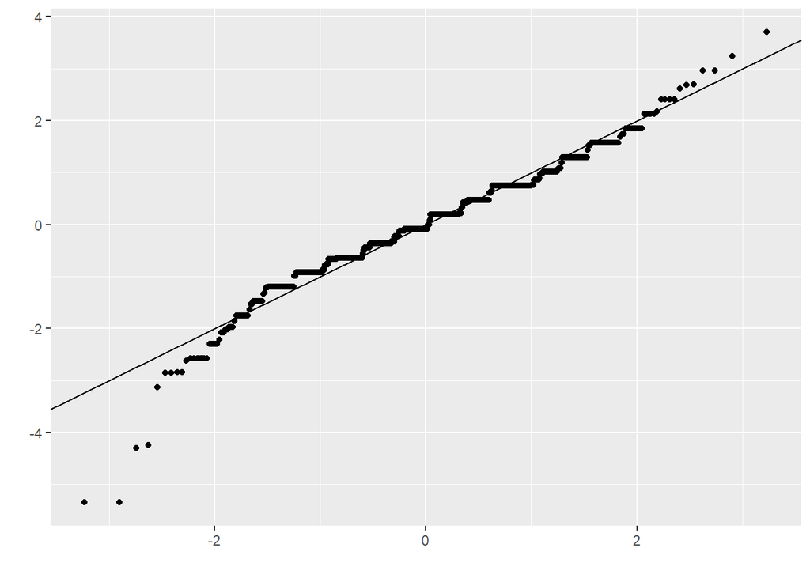

```r
# geom_abline 함수 통해 정규분포 선 추가.
qplot(sample = scale(x)) + # sample 논항 포함 시 QQ-플롯 쉽고 간단히 그려볼 수 있음.
  geom_abline()
```

- 예시 2: 산점도 생성하기

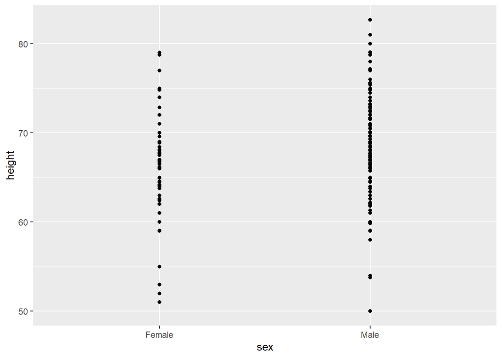

```r
# x축 범주변수(sex), y축 연속변수(height) 논항 투입하여 산점도 생성하기.
heights %>%
  qplot(sex, height, data = .)
```

- 예시 3: 상자 그래프 생성하기

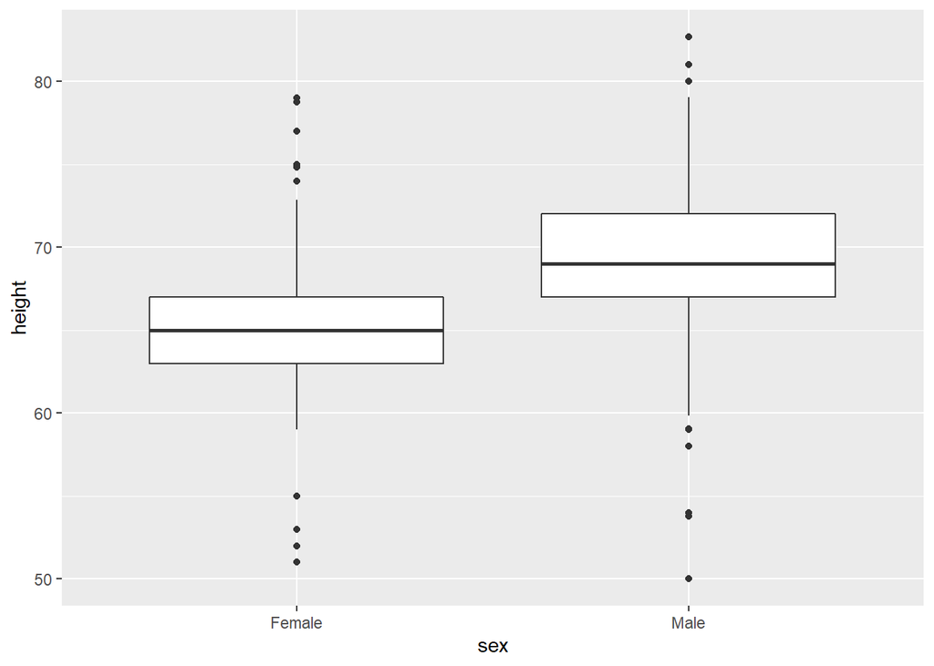

```r
# geom 논항을 "boxplot"으로 정의하여 상자 그래프 생성하기.
heights %>%
  qplot(sex, height, data = ., geom = "boxplot")
```

- 예시 4: 밀도 플롯 생성하기

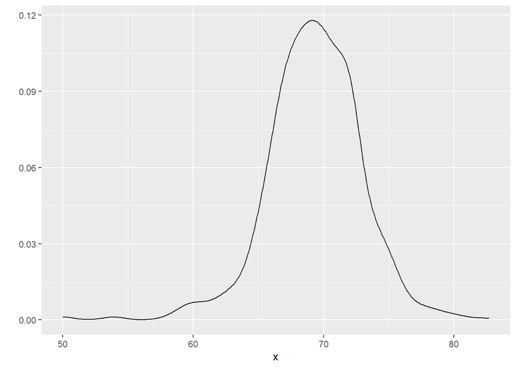

```r
# geom 논항을 "density"로 정의하여 밀도 플롯 생성하기.
qplot(x, geom = "density")
```

- 예시 5: 히스토그램 스타일 상세화하기

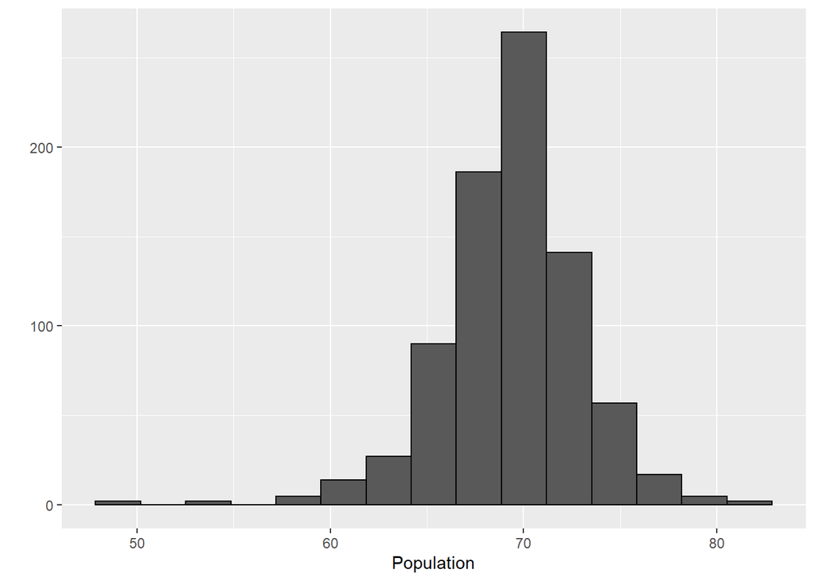

```r
# bins, color/colour, xlab 등의 논항 추가하기.
qplot(x, bins=15, color = I("black"), xlab = "Population") # 퀵 플롯은 자체 aes 함수에서 "black"을 문자(character)가 아닌 요인(factor)으로 처리함. 따라서 I 함수를 앞에 붙여 요인으로 변환하지 말고, 있는 그대로 읽어줄 것을 명령해야 함.
```

# References

Irizarry, R. A. (2022). *Introduction to data science: Data analysis and prediction algorithms with R*. Retrieved March 20, 2022 from https://rafalab.github.io/dsbook

Wickham, H., & Grolemund, G. (2017). *R for data science*. Retrieved March 20, 2022 from https://r4ds.had.co.nz